# R Notebook

#### Working Examples: A medical expert system to diagnose tubercolosis

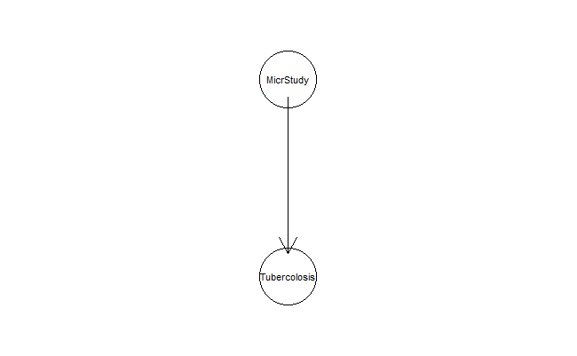

```r
val = c("true", "false")
F = cptable(~F, values = c(10,90), levels=val)
C = cptable(~C|F, values=c(10,90,20,80), levels=val )
E = cptable(~E|F, values=c(50,50,30,70), level=val )
A = cptable(~A|C, values=c(50,50,70,30), level=val)
D = cptable(~D|E, values=c(60,40,70,30), level=val)
B = cptable(~B|A:D, values=c(60,40,70,30,20,80,10,90), levels=val)
```

Because we have been giving the parents oF each variable every time we created a conditional probability table, we also have defined our graph completely. Therefore, the next step is to compute the junction tree. In most packages, computing the junction tree is done by calling one function because the algorithm just does everything at once:

```r
# This function compiles the CPT : "Conditional propability tree"
plist <- compileCPT(list(F,E,C,A,D,B))
plist
```

```
CPTspec with probabilities:
 P( F )
 P( E | F )
 P( C | F )
 P( A | C )
 P( D | E )
 P( B | A D )
```

This is indeed the factorization of our distribution as stated before. If we want to check further we can look at the conditional probability table of a few variables:

```r
print(plist$f)
```

[output not shown]

```r
print(plist$A)
```

```
       C
A       true false
  true   0.5   0.7
  false  0.5   0.3
```

```r
print(plist$B)
```

```
, , D = true

       A
B       true false
  true   0.6   0.7
  false  0.4   0.3

, , D = false

       A
B       true false
  true   0.2   0.1
  false  0.8   0.9
```

The second output is a bit more complex but if you look carefully you will see that you have two distributions: P(B|A,D=true) and P(B|A,D=false), which is a more readable presentation of P(B|A,D).

Now we can create the graph and run the junction tree algorithm

```r
jtree <- grain(plist)
jtree
```

```
Independence network: Compiled: FALSE Propagated: FALSE
  Nodes: chr [1:6] "F" "E" "C" "A" "D" "B"
```

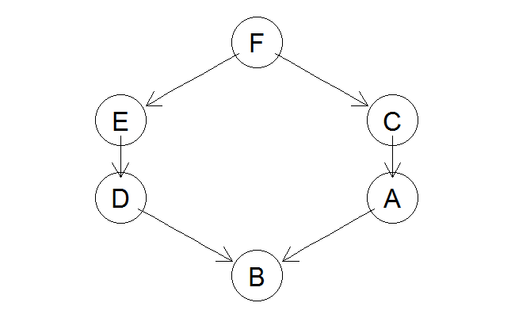

At this point, you might think, “Is that all?” Well, yes it is. Now that you have the junction tree representation of the graph you can perform any possible inference. And moreover, you only need to compute the junction tree once. Then all queries can be computed with the same junction tree. Of course, if you change the graph, then you need to recompute the junction tree.

#### Lets perform some basic queries

```r
querygrain(jtree, nodes=c("f"), type="marginal")
```

[output not shown]

```r
querygrain(jtree, nodes=c("C"), type = "marginal")
```

```
$C
C
 true false
 0.19  0.81
```

This is more interesting because it computes the marginal of C while we only stated the conditional distribution of C given F. We didn’t need to have a complex algorithm such as the junction tree algorithm to compute such a small marginal. The variable elimination algorithm we saw earlier would be enough, too.

But asking for the marginal of B, the variable elimination will not work because of the loop in the graph. The junction tree however will:

```r
querygrain(jtree, nodes=c("B"), type="marginal")
```

```
$B
B
    true    false
0.478564 0.521436
```

And we can ask for a more complex distribution, such as the **joint distribution** of B and A:

```r
querygrain(jtree, nodes=c("A", "B"), type="joint")
```

```
       B
A           true    false
  true  0.309272 0.352728
  false 0.169292 0.168708
```

#### Calculating the posterior distributions given a fact about a node

Now we want to observe a variable and compute the posterior distribution. Let’s say F=true and we want to propagate down this information to the rest of the network:

```r
querygrain(jtree2, nodes=c("F"), type="marginal")
```

```
$F
F
 true false
    1     0
```

This results in the following changes…

```r
querygrain(jtree2, nodes=c("B"), type="marginal")
```

```
$B
B
  true  false
0.4696 0.5304
```

### Setting more Evidence

```r
querygrain(jtree3, nodes=c("C"), type="marginal")
```

```
$C
C
   true   false
0.15625 0.84375
```

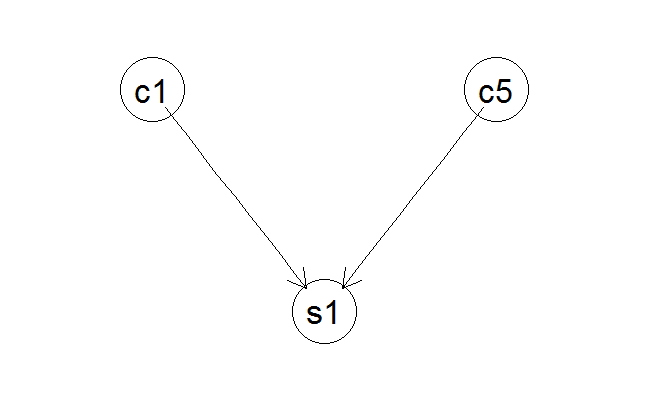

Learning the model from data

| Sepal.Length | Sepal.Width | Petal.Length | Petal.Width | Species |
| --- | --- | --- | --- | --- |
| 5.1 | 3.5 | 1.4 | 0.2 | setosa |
| 4.9 | 3.0 | 1.4 | 0.2 | setosa |
| 4.7 | 3.2 | 1.3 | 0.2 | setosa |
| 4.6 | 3.1 | 1.5 | 0.2 | setosa |
| 5.0 | 3.6 | 1.4 | 0.2 | setosa |
| 5.4 | 3.9 | 1.7 | 0.4 | setosa |
| 4.6 | 3.4 | 1.4 | 0.3 | setosa |
| 5.0 | 3.4 | 1.5 | 0.2 | setosa |
| 4.4 | 2.9 | 1.4 | 0.2 | setosa |
| 4.9 | 3.1 | 1.5 | 0.1 | setosa |

[output cut: 140 more lines]

```r
daply(iris, .(Species),nrow) / nrow(iris)
```

```
    setosa versicolor  virginica
 0.3333333  0.3333333  0.3333333
```

This gives us a roughly uniform distribution of all entries over all three classes in the dataset

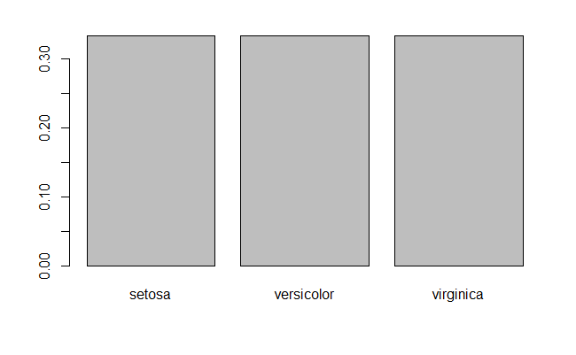

Computing the conditional distribution P(SepalLength | Class) is the equivalent of computing all the mean and variance values for each value of the class variable. It is done by running:

```r
daply(iris, .(Species), function(n){mean(n$Sepal.Length)} )
```

```
    setosa versicolor  virginica
     5.006      5.936      6.588
```

The variances of each distritubiton ondictioned on the class variable

```r
daply(iris, .(Species), function(n){var(n$Sepal.Length)})
```

```
    setosa versicolor  virginica
 0.1242490  0.2664327  0.4043429
```

If we want to compute the same thing for discrete distributions, we could use the following code.

| Sepal.Length | Sepal.Width | Petal.Length | Petal.Width | Species | dsw |
| --- | --- | --- | --- | --- | --- |
| 5.1 | 3.5 | 1.4 | 0.2 | setosa | large |
| 4.9 | 3.0 | 1.4 | 0.2 | setosa | medium |
| 4.7 | 3.2 | 1.3 | 0.2 | setosa | large |
| 4.6 | 3.1 | 1.5 | 0.2 | setosa | medium |
| 5.0 | 3.6 | 1.4 | 0.2 | setosa | large |
| 5.4 | 3.9 | 1.7 | 0.4 | setosa | large |
| 4.6 | 3.4 | 1.4 | 0.3 | setosa | large |
| 5.0 | 3.4 | 1.5 | 0.2 | setosa | large |
| 4.4 | 2.9 | 1.4 | 0.2 | setosa | medium |
| 4.9 | 3.1 | 1.5 | 0.1 | setosa | medium |

[output cut: 140 more lines]

Now we can learn the conditional propability distribution for dsw given Species:

```r
p1
```

```
        Species
dsw      setosa versicolor virginica
  large      38          5        13
  medium     11         18        18
  small       1         27        19
```